# Non-Linear Pendulum Lab

# Large Angle

It is straightforward to numerically solve the eqautions of motion for *any* $\theta_0$. For 45° $\sin(45°) = 0.7071$, but $\theta = 0.7854$, so the small angle approximation is off by about 10%.

Let's see the solutions.

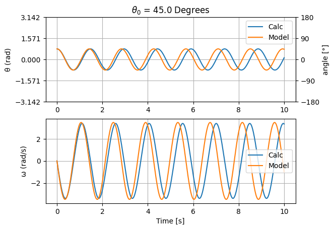

```python
th_i_deg = 45.0
om_i_deg =   0.0

th_i = np.deg2rad(th_i_deg)
om_i = np.deg2rad(om_i_deg)

out = sp.integrate.odeint(pendulum, (th_i, om_i), t_axis)
th_calc = out[:,0]
om_calc = out[:,1]

th_model = th_i * np.cos(OM_0 * t_axis)
om_model = -th_i * OM_0 * np.sin(OM_0 * t_axis)
plt.subplot(2,1,1)
plt.plot(t_axis, th_calc, label="Calc")
plt.plot(t_axis, th_model, label='Model')
plt.title("$θ_0$ = %.1f Degrees" % (th_i_deg))
plt.grid()
plt.legend()
plt.ylabel("θ (rad)")
plt.yticks(np.array((-1,-.5,0,.5,1))*np.pi)
plt.ylim(-np.pi, np.pi)

# Get fancy with y axis
secax = plt.gca().secondary_yaxis('right', functions=(np.rad2deg, np.deg2rad))
secax.set_ylabel('angle [°]')
secax.set_ylim(-180, 180)
secax.set_yticks((-180,-90,0,90,180))

plt.subplot(2,1,2)
plt.plot(t_axis, om_calc, label="Calc")
plt.plot(t_axis, om_model, label='Model')
plt.xlabel("Time [s]")
plt.ylabel("ω (rad/s)")
plt.grid()
plt.legend()

pass
```

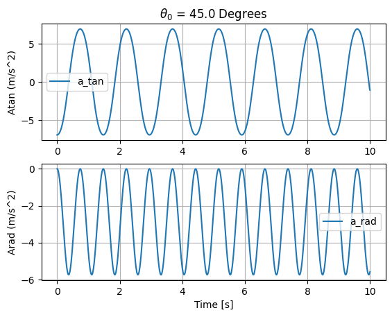

```python
# Calculate radial and tangental accelerations
## Tangental
om_dot = np.gradient(om_calc, dt)
a_tan = L * om_dot

## Radial
v = L * om_calc
a_rad = -v**2 / L

plt.subplot(2,1,1)
plt.plot(t_axis, a_tan, label="a_tan")
plt.grid()
plt.legend()
plt.title("$θ_0$ = %.1f Degrees" % (th_i_deg))
plt.ylabel("Atan (m/s^2)")

plt.subplot(2,1,2)
plt.plot(t_axis, a_rad, label="a_rad")
plt.xlabel("Time [s]")
plt.ylabel("Arad (m/s^2)")
plt.grid()
plt.legend()

pass
```

The observation that jumps out is that the numerical solution looks like a sinusoid, but the frequency is lower. Intuitively this makes sense. If you play with the pendulum, you can see for very large angles, it takes longer to oscillate, so the frequency is lower.

Let's look at two more examples.

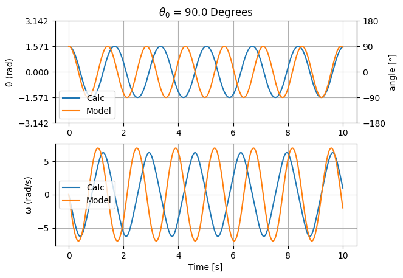

```python
th_i_deg = 90.0
om_i_deg =   0.0

th_i = np.deg2rad(th_i_deg)
om_i = np.deg2rad(om_i_deg)

out = sp.integrate.odeint(pendulum, (th_i, om_i), t_axis)
th_calc = out[:,0]
om_calc = out[:,1]

th_model = th_i * np.cos(OM_0 * t_axis)
om_model = -th_i * OM_0 * np.sin(OM_0 * t_axis)
plt.subplot(2,1,1)
plt.plot(t_axis, th_calc, label="Calc")
plt.plot(t_axis, th_model, label='Model')
plt.title("$θ_0$ = %.1f Degrees" % (th_i_deg))
plt.grid()
plt.legend()
plt.ylabel("θ (rad)")
plt.yticks(np.array((-1,-.5,0,.5,1))*np.pi)
plt.ylim(-np.pi, np.pi)

# Get fancy with y axis
secax = plt.gca().secondary_yaxis('right', functions=(np.rad2deg, np.deg2rad))
secax.set_ylabel('angle [°]')
secax.set_ylim(-180, 180)
secax.set_yticks((-180,-90,0,90,180))

plt.subplot(2,1,2)
plt.plot(t_axis, om_calc, label="Calc")
plt.plot(t_axis, om_model, label='Model')
plt.xlabel("Time [s]")
plt.ylabel("ω (rad/s)")
plt.grid()
plt.legend()

pass
```

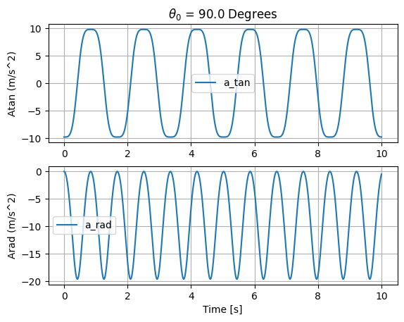

```python
# Calculate radial and tangental accelerations
## Tangental
om_dot = np.gradient(om_calc, dt)
a_tan = L * om_dot

## Radial
v = L * om_calc
a_rad = -v**2 / L

plt.subplot(2,1,1)
plt.plot(t_axis, a_tan, label="a_tan")
plt.grid()
plt.legend()
plt.title("$θ_0$ = %.1f Degrees" % (th_i_deg))
plt.ylabel("Atan (m/s^2)")

plt.subplot(2,1,2)
plt.plot(t_axis, a_rad, label="a_rad")
plt.xlabel("Time [s]")
plt.ylabel("Arad (m/s^2)")
plt.grid()
plt.legend()

pass
```

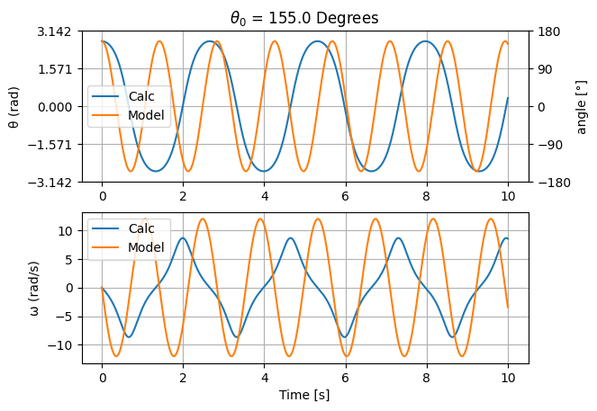

```python
th_i_deg = 155.0
om_i_deg =   0.0

th_i = np.deg2rad(th_i_deg)
om_i = np.deg2rad(om_i_deg)

out = sp.integrate.odeint(pendulum, (th_i, om_i), t_axis)
th_calc = out[:,0]
om_calc = out[:,1]

th_model = th_i * np.cos(OM_0 * t_axis)
om_model = -th_i * OM_0 * np.sin(OM_0 * t_axis)
plt.subplot(2,1,1)
plt.plot(t_axis, th_calc, label="Calc")
plt.plot(t_axis, th_model, label='Model')
plt.title("$θ_0$ = %.1f Degrees" % (th_i_deg))
plt.grid()
plt.legend()
plt.ylabel("θ (rad)")
plt.yticks(np.array((-1,-.5,0,.5,1))*np.pi)
plt.ylim(-np.pi, np.pi)

# Get fancy with y axis
secax = plt.gca().secondary_yaxis('right', functions=(np.rad2deg, np.deg2rad))
secax.set_ylabel('angle [°]')
secax.set_ylim(-180, 180)
secax.set_yticks((-180,-90,0,90,180))

plt.subplot(2,1,2)
plt.plot(t_axis, om_calc, label="Calc")
plt.plot(t_axis, om_model, label='Model')
plt.xlabel("Time [s]")
plt.ylabel("ω (rad/s)")
plt.grid()
plt.legend()

pass
```

# Solutions to the Non-Linear Pendulum

From *An analysis of the large amplitude simple pendulum using Fourier series*, Brennen Black and Vetri Vel, Am. J. Phys. 91, 776–782 (2023), https://doi.org/10.1119/5.0130943

They find an approximate solution by doing Fourier analysis. They assume a solution of the form $$ θ(θ_0, t) = \sum_{n=0}^\infty{\alpha_n} \cos(n Ω t) $$ where Ω is the period. The fifth order solution is $$ \begin{align} \alpha_1 &= θ_0 + θ_0^3 / 192 + 17 θ_0^5 / 61440 \\ \alpha_3 &= -θ_0^3 / 192 - θ_0^5 / 3072 \\ \alpha_5 &= θ_0^5 / 20480 \\ T &= T_0 / (1 - θ_0^2 / 16 + θ_0^4 / 3072 - 23 θ_0^6 / 737280 \end{align} $$ where $T = 2 \pi / Ω$.

The cell below codes this function.

```python
def pend5th(th0, t):
    alf1 = th0 + th0**3 / 192 + 17 * th0**5 / 61440
    alf3 = -th0**3 / 192 - th0**5 / 3072
    alf5 = th0**5 / 20480

    T = T_0 / (1.0 - th0**2 / 16 + th0**4 / 3072 - 23 * th0**6 / 737280)
    OMEGA = 2 * np.pi / T

    return alf1 * np.cos(OMEGA * t) + alf3 * np.cos(3 * OMEGA * t) + alf5 * np.cos(5 * OMEGA * t)

def omega5th(th0, t):
    alf1 = th0 + th0**3 / 192 + 17 * th0**5 / 61440
    alf3 = -th0**3 / 192 - th0**5 / 3072
    alf5 = th0**5 / 20480

    T = T_0 / (1.0 - th0**2 / 16 + th0**4 / 3072 - 23 * th0**6 / 737280)
    OMEGA = 2 * np.pi / T

    return -alf1 * OMEGA * np.sin(OMEGA * t) + \
            -alf3 * 3 * OMEGA * np.sin(3 * OMEGA * t) + \
            -alf5 * 5 * OMEGA * np.sin(5 * OMEGA * t)
```

# Comparison

At $θ_0 < 120°$ the agreement is excellent. The cell below shows the result for 135°, which is also decent.

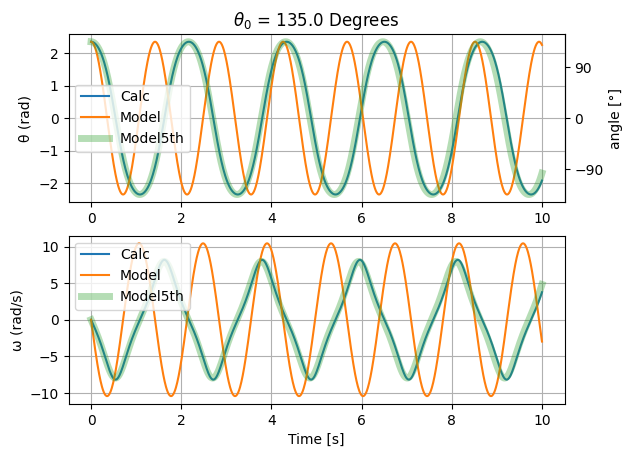

```python
th_i_deg = 135.0
om_i_deg =   0.0

th_i = np.deg2rad(th_i_deg)
om_i = np.deg2rad(om_i_deg)

out = sp.integrate.odeint(pendulum, (th_i, om_i), t_axis)
th_calc = out[:,0]
om_calc = out[:,1]

th_model = th_i * np.cos(OM_0 * t_axis)
th_model5th = pend5th(th_i, t_axis)
om_model = -th_i * OM_0 * np.sin(OM_0 * t_axis)
om_model5th = omega5th(th_i, t_axis)
plt.subplot(2,1,1)
plt.plot(t_axis, th_calc, label="Calc")
plt.plot(t_axis, th_model, label='Model')
plt.plot(t_axis, th_model5th, label='Model5th', lw=5, alpha=0.35)
plt.title("$θ_0$ = %.1f Degrees" % (th_i_deg))
plt.grid()
plt.legend()
plt.ylabel("θ (rad)")
# plt.yticks(np.array((-1,-.5,0,.5,1))*np.pi)
# plt.ylim(-np.pi, np.pi)

# Get fancy with y axis
secax = plt.gca().secondary_yaxis('right', functions=(np.rad2deg, np.deg2rad))
secax.set_ylabel('angle [°]')
secax.set_ylim(-180, 180)
secax.set_yticks((-180,-90,0,90,180))

plt.subplot(2,1,2)
plt.plot(t_axis, om_calc, label="Calc")
plt.plot(t_axis, om_model, label='Model')
plt.plot(t_axis, om_model5th, label='Model5th',lw=5, alpha=0.35)
plt.xlabel("Time [s]")
plt.ylabel("ω (rad/s)")
plt.grid()
plt.legend()

pass
```

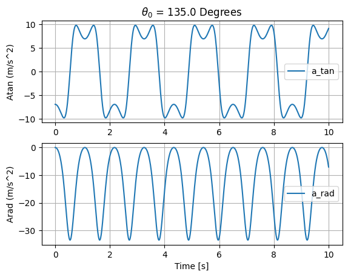

```python
# Calculate radial and tangental accelerations
## Tangental
om_dot = np.gradient(om_calc, dt)
a_tan = L * om_dot

## Radial
v = L * om_calc
a_rad = -v**2 / L

plt.subplot(2,1,1)
plt.plot(t_axis, a_tan, label="a_tan")
plt.grid()
plt.legend()
plt.title("$θ_0$ = %.1f Degrees" % (th_i_deg))
plt.ylabel("Atan (m/s^2)")

plt.subplot(2,1,2)
plt.plot(t_axis, a_rad, label="a_rad")
plt.xlabel("Time [s]")
plt.ylabel("Arad (m/s^2)")
plt.grid()
plt.legend()

pass
```